# Red Wine Exploration

### by Karina

```
## [1] 1599
```

```
##        X          fixed.acidity   volatile.acidity  citric.acid
##  Min.   :   1.0   Min.   : 4.60   Min.   :0.1200   Min.   :0.000
##  1st Qu.: 400.5   1st Qu.: 7.10   1st Qu.:0.3900   1st Qu.:0.090
##  Median : 800.0   Median : 7.90   Median :0.5200   Median :0.260
##  Mean   : 800.0   Mean   : 8.32   Mean   :0.5278   Mean   :0.271
##  3rd Qu.:1199.5   3rd Qu.: 9.20   3rd Qu.:0.6400   3rd Qu.:0.420
##  Max.   :1599.0   Max.   :15.90   Max.   :1.5800   Max.   :1.000
##  residual.sugar     chlorides       free.sulfur.dioxide
##  Min.   : 0.900   Min.   :0.01200   Min.   : 1.00
##  1st Qu.: 1.900   1st Qu.:0.07000   1st Qu.: 7.00
##  Median : 2.200   Median :0.07900   Median :14.00
##  Mean   : 2.539   Mean   :0.08747   Mean   :15.87
##  3rd Qu.: 2.600   3rd Qu.:0.09000   3rd Qu.:21.00
##  Max.   :15.500   Max.   :0.61100   Max.   :72.00
##  total.sulfur.dioxide    density             pH          sulphates
##  Min.   :  6.00       Min.   :0.9901   Min.   :2.740   Min.   :0.3300
##  1st Qu.: 22.00       1st Qu.:0.9956   1st Qu.:3.210   1st Qu.:0.5500
##  Median : 38.00       Median :0.9968   Median :3.310   Median :0.6200
##  Mean   : 46.47       Mean   :0.9967   Mean   :3.311   Mean   :0.6581
##  3rd Qu.: 62.00       3rd Qu.:0.9978   3rd Qu.:3.400   3rd Qu.:0.7300
##  Max.   :289.00       Max.   :1.0037   Max.   :4.010   Max.   :2.0000
##     alcohol         quality
##  Min.   : 8.40   Min.   :3.000
##  1st Qu.: 9.50   1st Qu.:5.000
##  Median :10.20   Median :6.000
##  Mean   :10.42   Mean   :5.636
##  3rd Qu.:11.10   3rd Qu.:6.000
##  Max.   :14.90   Max.   :8.000
```

# Univariate Plots Section

```
##  fixed.acidity   volatile.acidity  citric.acid    residual.sugar
##  Min.   : 4.60   Min.   :0.1200   Min.   :0.000   Min.   : 0.900
##  1st Qu.: 7.10   1st Qu.:0.3900   1st Qu.:0.090   1st Qu.: 1.900
##  Median : 7.90   Median :0.5200   Median :0.260   Median : 2.200
##  Mean   : 8.32   Mean   :0.5278   Mean   :0.271   Mean   : 2.539
##  3rd Qu.: 9.20   3rd Qu.:0.6400   3rd Qu.:0.420   3rd Qu.: 2.600
##  Max.   :15.90   Max.   :1.5800   Max.   :1.000   Max.   :15.500
##    chlorides       free.sulfur.dioxide total.sulfur.dioxide
##  Min.   :0.01200   Min.   : 1.00       Min.   :  6.00
##  1st Qu.:0.07000   1st Qu.: 7.00       1st Qu.: 22.00
##  Median :0.07900   Median :14.00       Median : 38.00
##  Mean   :0.08747   Mean   :15.87       Mean   : 46.47
##  3rd Qu.:0.09000   3rd Qu.:21.00       3rd Qu.: 62.00
##  Max.   :0.61100   Max.   :72.00       Max.   :289.00
##     density             pH          sulphates         alcohol
##  Min.   :0.9901   Min.   :2.740   Min.   :0.3300   Min.   : 8.40
##  1st Qu.:0.9956   1st Qu.:3.210   1st Qu.:0.5500   1st Qu.: 9.50
##  Median :0.9968   Median :3.310   Median :0.6200   Median :10.20
##  Mean   :0.9967   Mean   :3.311   Mean   :0.6581   Mean   :10.42
##  3rd Qu.:0.9978   3rd Qu.:3.400   3rd Qu.:0.7300   3rd Qu.:11.10
##  Max.   :1.0037   Max.   :4.010   Max.   :2.0000   Max.   :14.90
##     quality
##  Min.   :3.000
##  1st Qu.:5.000
##  Median :6.000
##  Mean   :5.636
##  3rd Qu.:6.000
##  Max.   :8.000
```

Here is the summary of all attributes that are present in dataset. It can be noticed that for quality column, in a scale 0-10, the maximum value observed  
here is 8 and the minimum is 3 with a mean value of ca. 5.6.

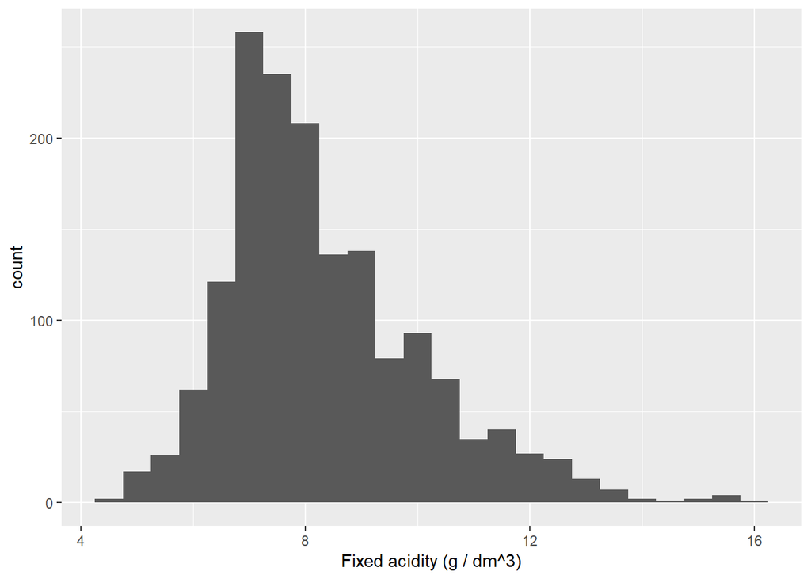

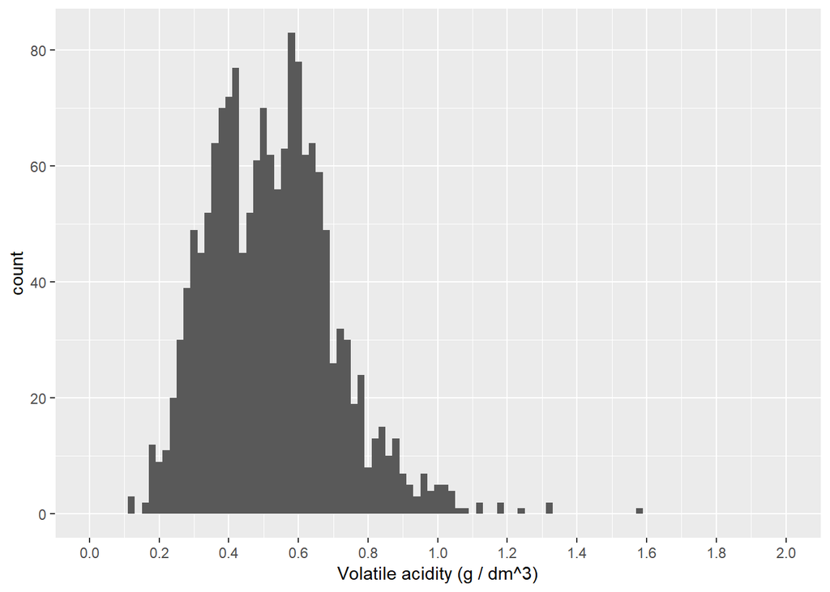

Here above we can notice that the majority of the observations have volatile acidity  
above 0.1 and below 1.0.

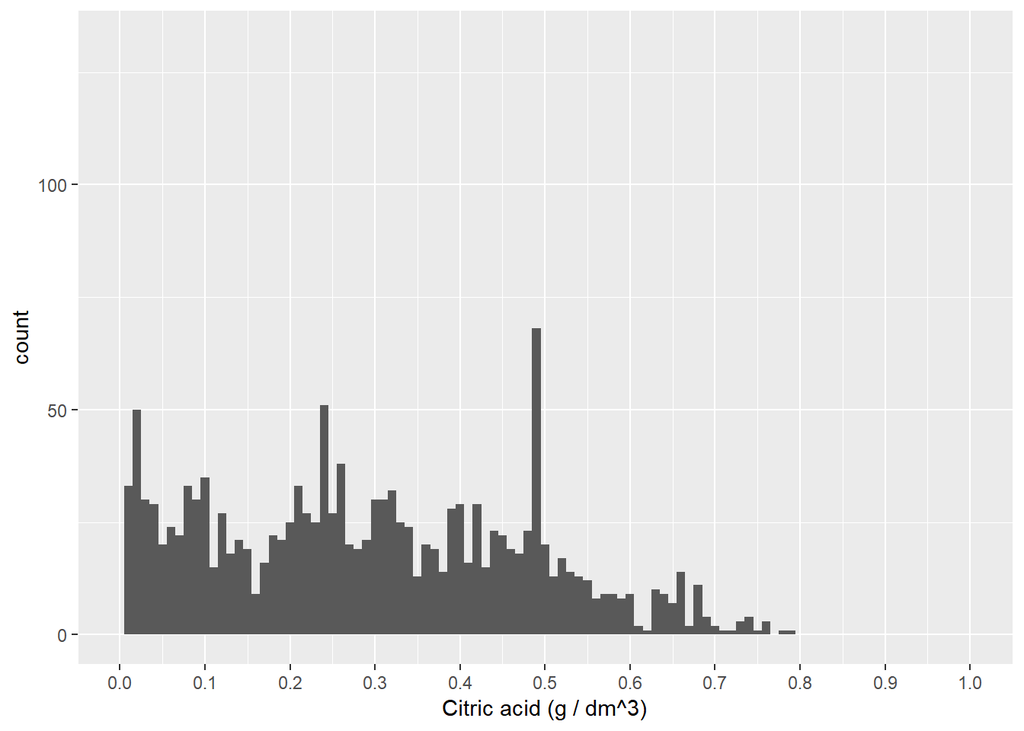

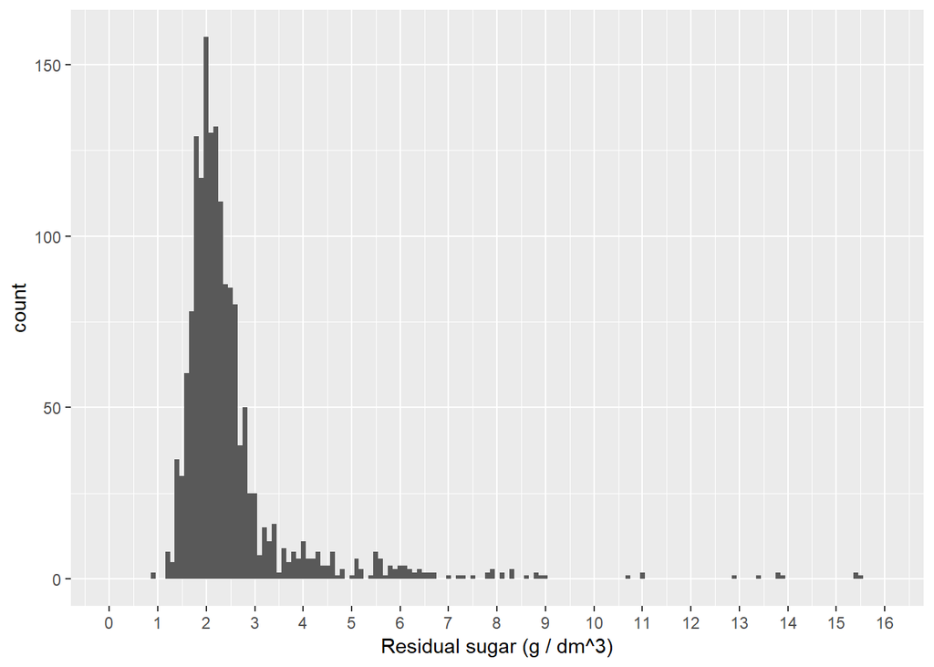

The great majority of observations have value of residual sugar above 1 and  
below 3.5.

```
## redwines$quality: 3
##    Min. 1st Qu.  Median    Mean 3rd Qu.    Max.
##  0.0610  0.0790  0.0905  0.1225  0.1430  0.2670
## --------------------------------------------------------
## redwines$quality: 4
##    Min. 1st Qu.  Median    Mean 3rd Qu.    Max.
## 0.04500 0.06700 0.08000 0.09068 0.08900 0.61000
## --------------------------------------------------------
## redwines$quality: 5
##    Min. 1st Qu.  Median    Mean 3rd Qu.    Max.
## 0.03900 0.07400 0.08100 0.09274 0.09400 0.61100
## --------------------------------------------------------
## redwines$quality: 6
##    Min. 1st Qu.  Median    Mean 3rd Qu.    Max.
## 0.03400 0.06825 0.07800 0.08496 0.08800 0.41500
## --------------------------------------------------------
## redwines$quality: 7
##    Min. 1st Qu.  Median    Mean 3rd Qu.    Max.
## 0.01200 0.06200 0.07300 0.07659 0.08700 0.35800
## --------------------------------------------------------
## redwines$quality: 8
##    Min. 1st Qu.  Median    Mean 3rd Qu.    Max.
## 0.04400 0.06200 0.07050 0.06844 0.07550 0.08600
```

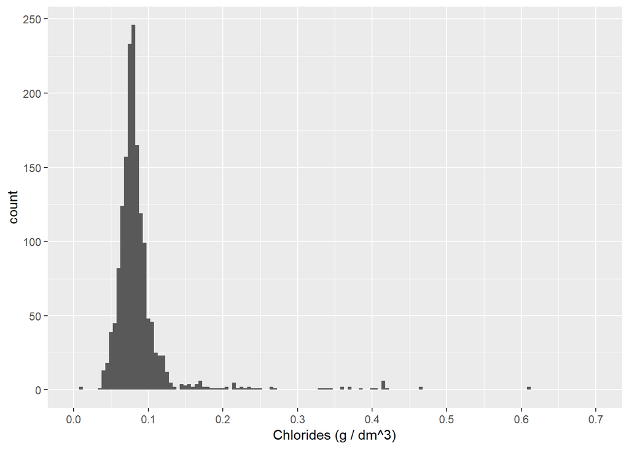

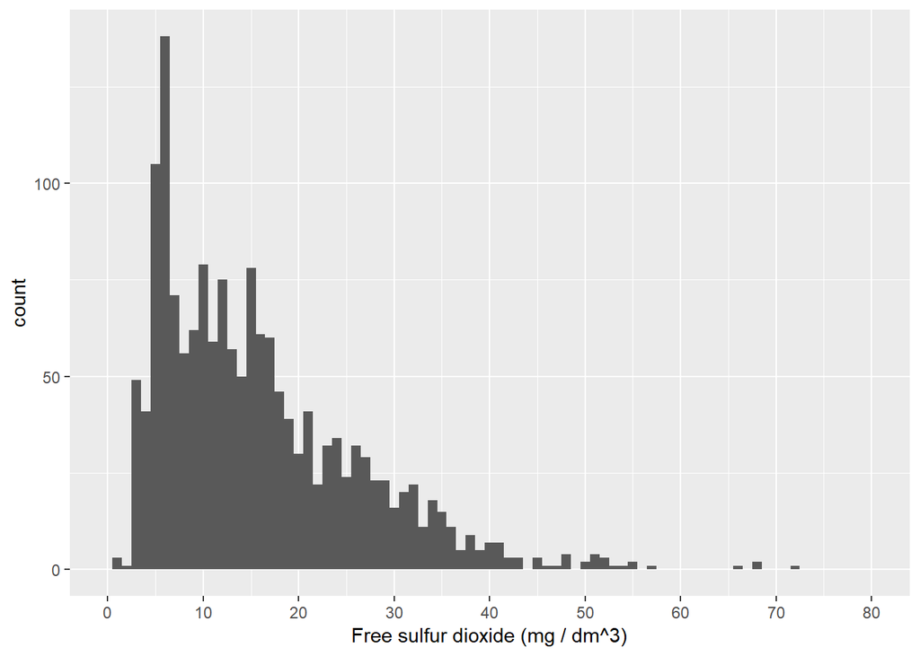

Concentration of observations is on lower values and decreases for higher values.

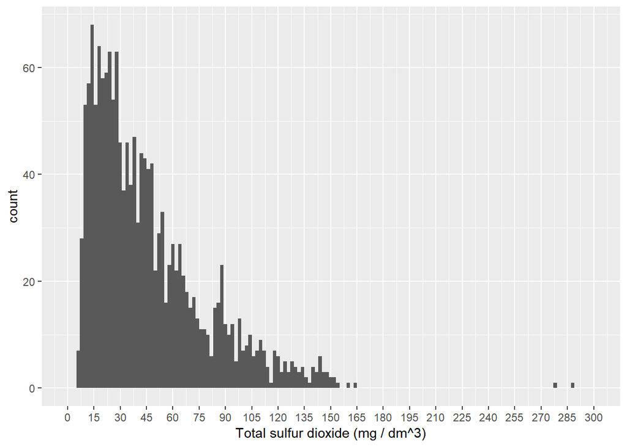

Almost for all characteristics, the values of the oberservations concentrate on  
the first half of the range of the existing values.

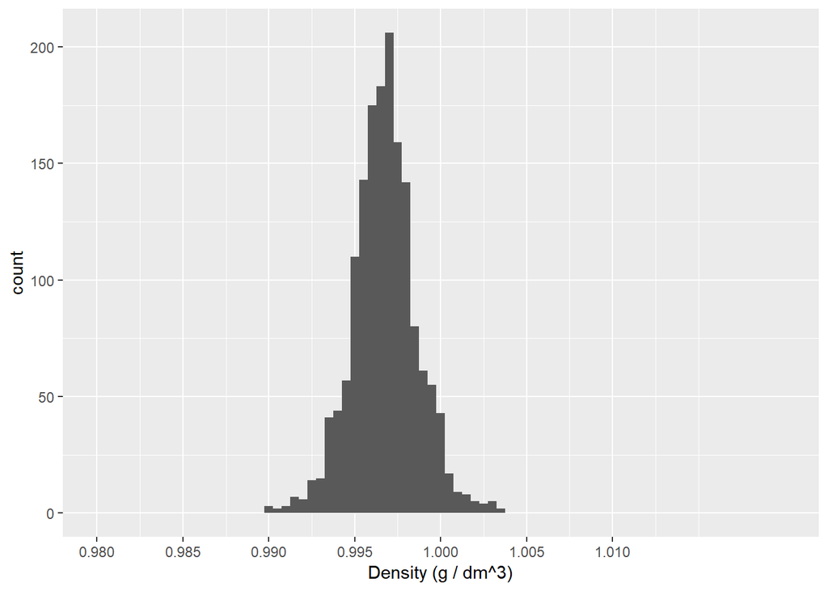

The majority of wines here presented have density close to 0.997, a little  
lower than the value of the water’s density (1.0).

```
## redwines$quality: 3
##    Min. 1st Qu.  Median    Mean 3rd Qu.    Max.
##   3.160   3.312   3.390   3.398   3.495   3.630
## --------------------------------------------------------
## redwines$quality: 4
##    Min. 1st Qu.  Median    Mean 3rd Qu.    Max.
##   2.740   3.300   3.370   3.382   3.500   3.900
## --------------------------------------------------------
## redwines$quality: 5
##    Min. 1st Qu.  Median    Mean 3rd Qu.    Max.
##   2.880   3.200   3.300   3.305   3.400   3.740
## --------------------------------------------------------
## redwines$quality: 6
##    Min. 1st Qu.  Median    Mean 3rd Qu.    Max.
##   2.860   3.220   3.320   3.318   3.410   4.010
## --------------------------------------------------------
## redwines$quality: 7
##    Min. 1st Qu.  Median    Mean 3rd Qu.    Max.
##   2.920   3.200   3.280   3.291   3.380   3.780
## --------------------------------------------------------
## redwines$quality: 8
##    Min. 1st Qu.  Median    Mean 3rd Qu.    Max.
##   2.880   3.163   3.230   3.267   3.350   3.720
```

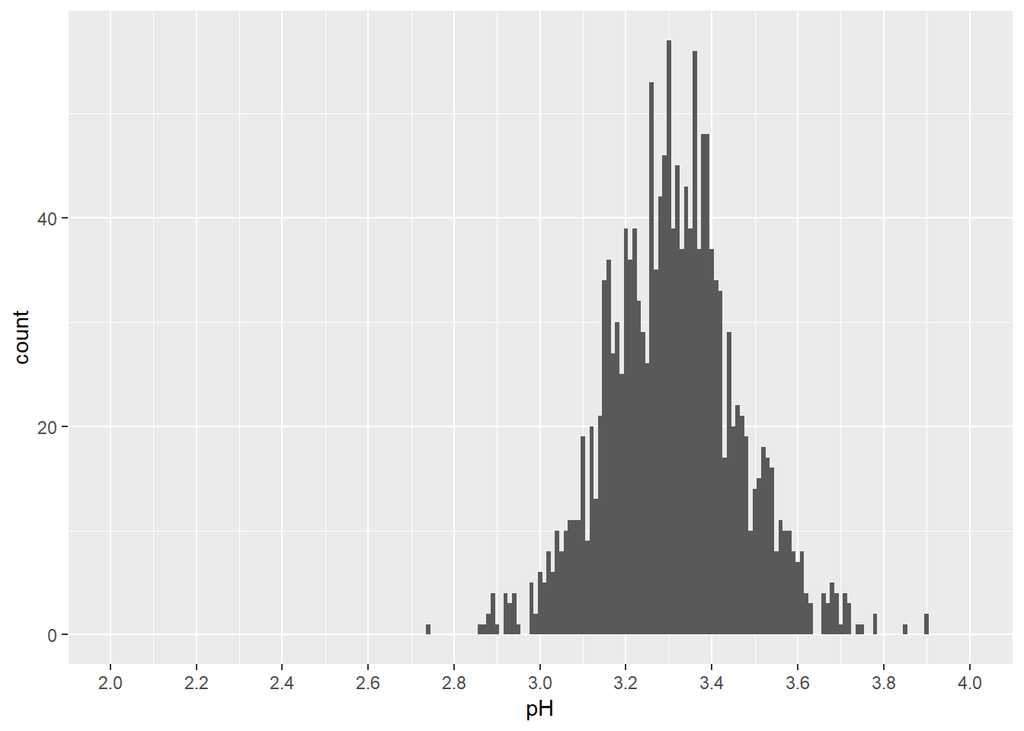

```
##    Min. 1st Qu.  Median    Mean 3rd Qu.    Max.
##   2.740   3.210   3.310   3.311   3.400   4.010
```

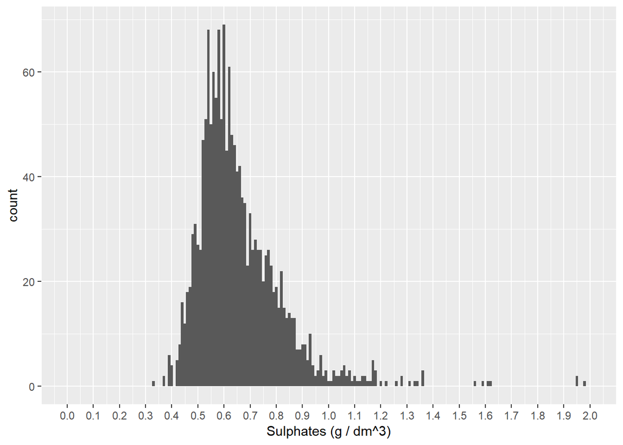

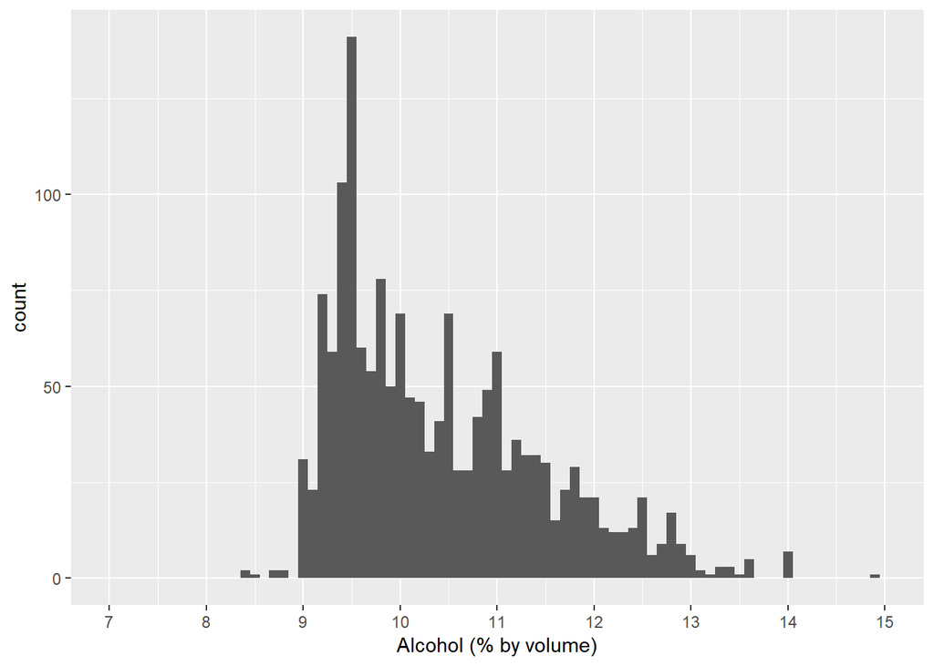

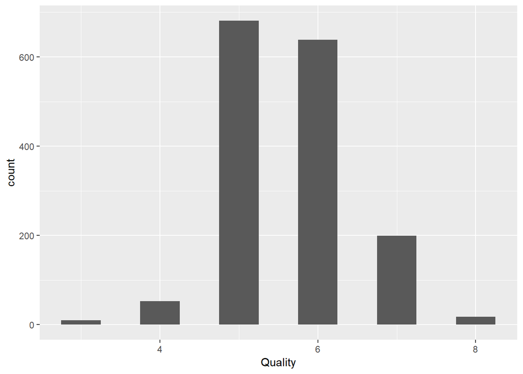

# Univariate Analysis

### What is the structure of your dataset?

The dataset is composed of 1599 red wine observations, for which 11 features were extracted from physicochemical tests and 1 feature extracted through  
sensorial data.

### What is/are the main feature(s) of interest in your dataset?

The main feature of interest here in this dataset is the quality.

### What other features in the dataset do you think will help support your investigation into your feature(s) of interest?

The ones that will help me I think will be residual sugar, pH and maybe alcohol.

### Did you create any new variables from existing variables in the dataset?

### Of the features you investigated, were there any unusual distributions? Did you perform any operations on the data to tidy, adjust, or change the form of the data? If so, why did you do this?

All values were used in their raw form, except for those where there were some  
missing values, these were removed when plotting graphs.

# Bivariate Plots Section

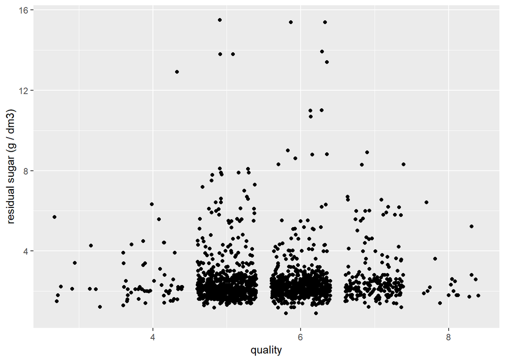

In this graph above, for lower levels of residual sugar (lower than 4 g/dm^3) concentration of points is higher and for higher levels, this distribution becomes sparse. It seems that residual sugar don’t influence much in quality of wine.

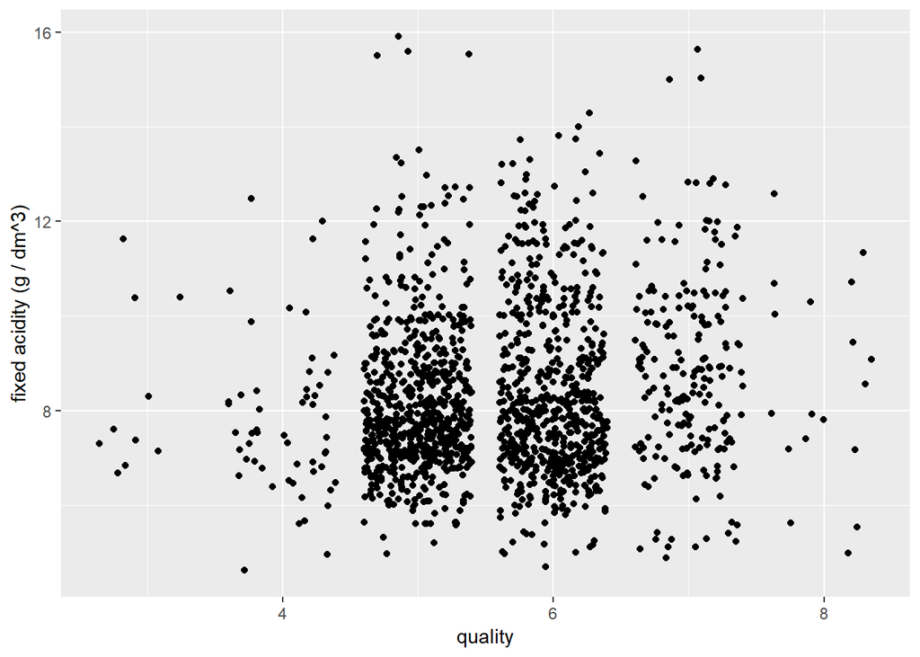

It can be noticed that for some value a little lower than 8 g/dm^3 of fixed acidity, the concentration of points on qualities 5 and 6 is the highest. On the other hand, for quality 7 and above the distribution of points is sparse.

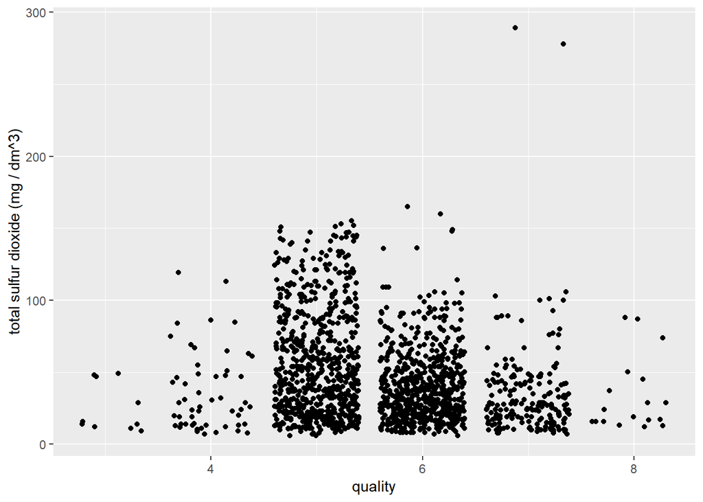

The main point to notice for the graph above is that for values of total sulfur dioxide lower than ca. 50 mg/dm^3 the concentration of points is higher for quality 5 and 6 and a little less for 7. Moreover, for values above 50 mg/dm^3, the concentration of points resides in qualities 5 and 6 and for 100 and above in quality 5 (except for some outliers present in dataset).

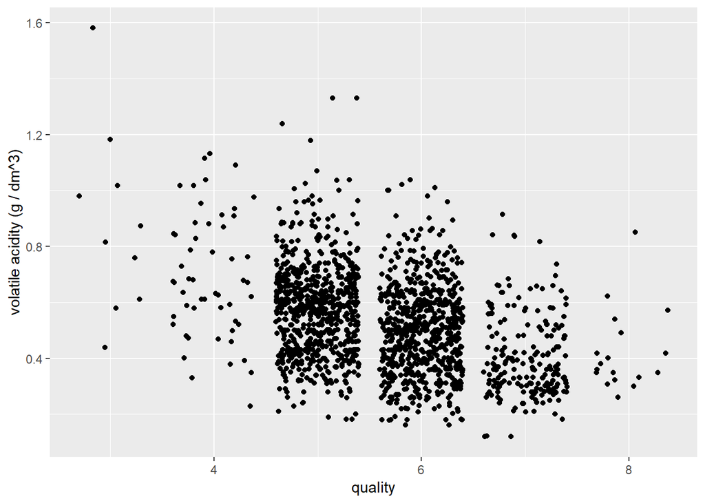

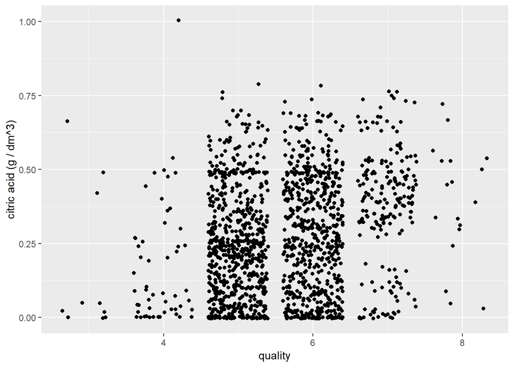

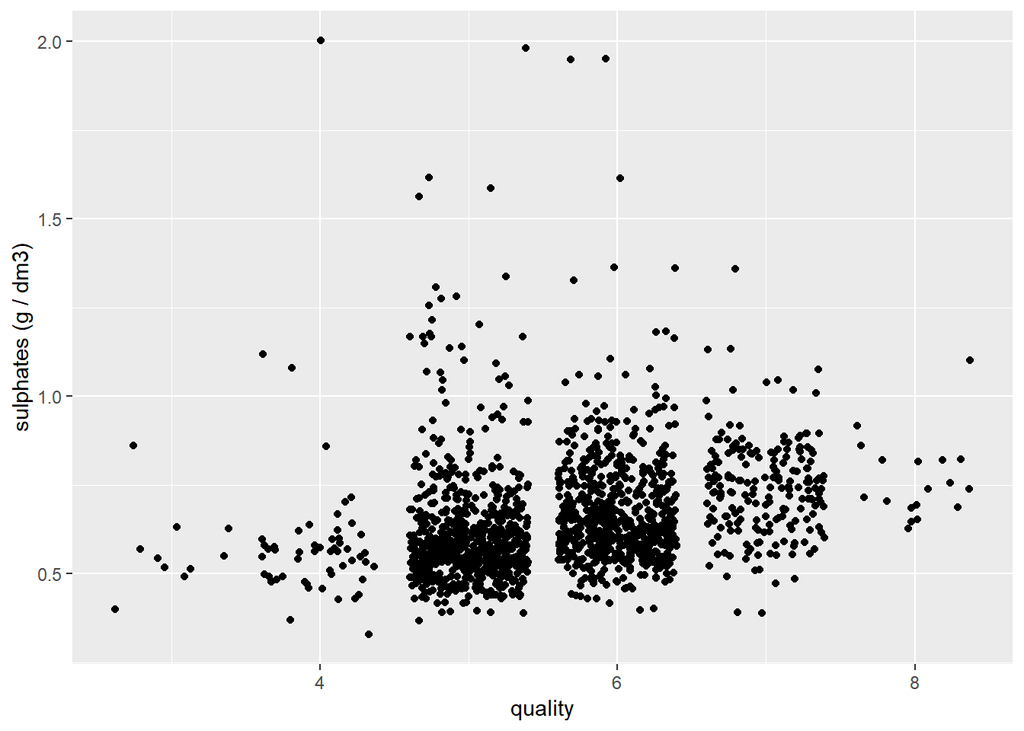

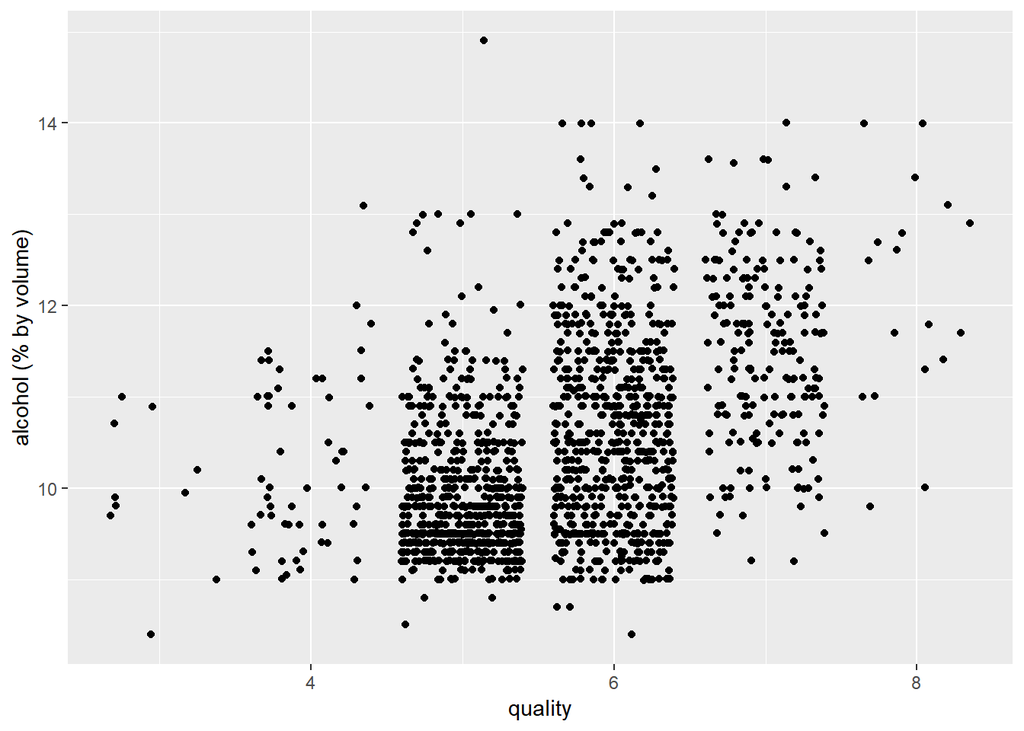

All the characteristics plotted here showed some influence in ethe quality of wine while the rest of the characteristics didn’t showed as much importance. For these graphs above we can see approximately that for some value the concentrations of points is higher for qualities 5 and 6 (that is near to the mean value) and for other value these concentration tends to decrease while the one for higher qualities tends to increase.

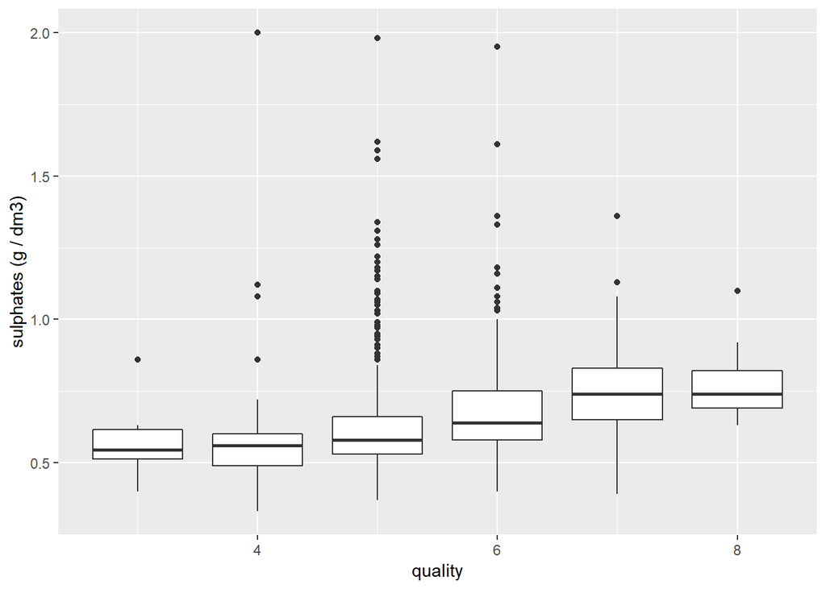

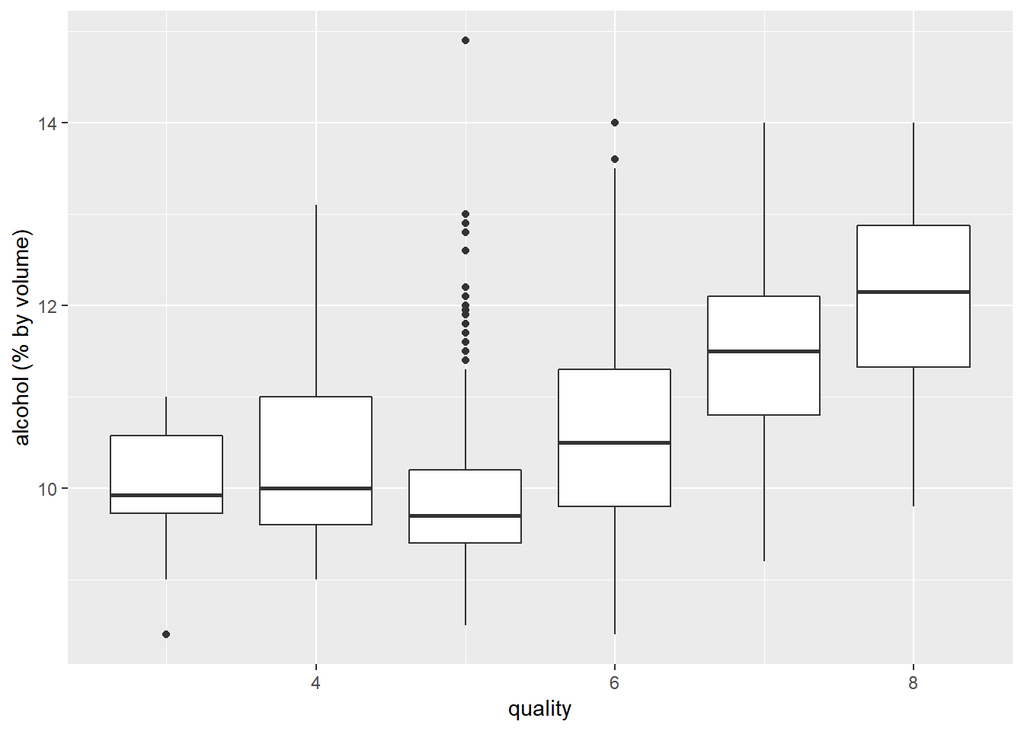

For these boxplots, it is clear that for different qualities there are different mean values for alcohol and sulphates, indicating some correlation between the characteristic and wine’s quality.

# Bivariate Analysis

### Did you observe any interesting relationships between the other features (not the main feature(s) of interest)?

Among other features, it seemed that they does not incluence quality as much, as in the case of residual sugar.

### What was the strongest relationship you found?

The strongest relationship found, confirmed by the boxplot, was the relation between alcohol and quality.

# Multivariate Plots Section

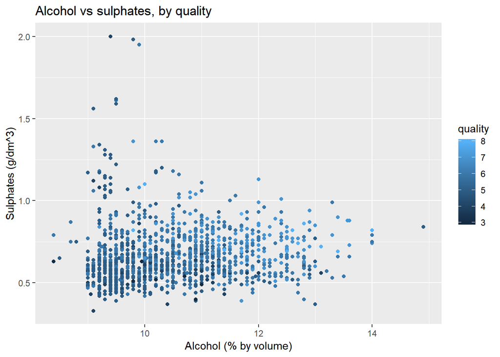

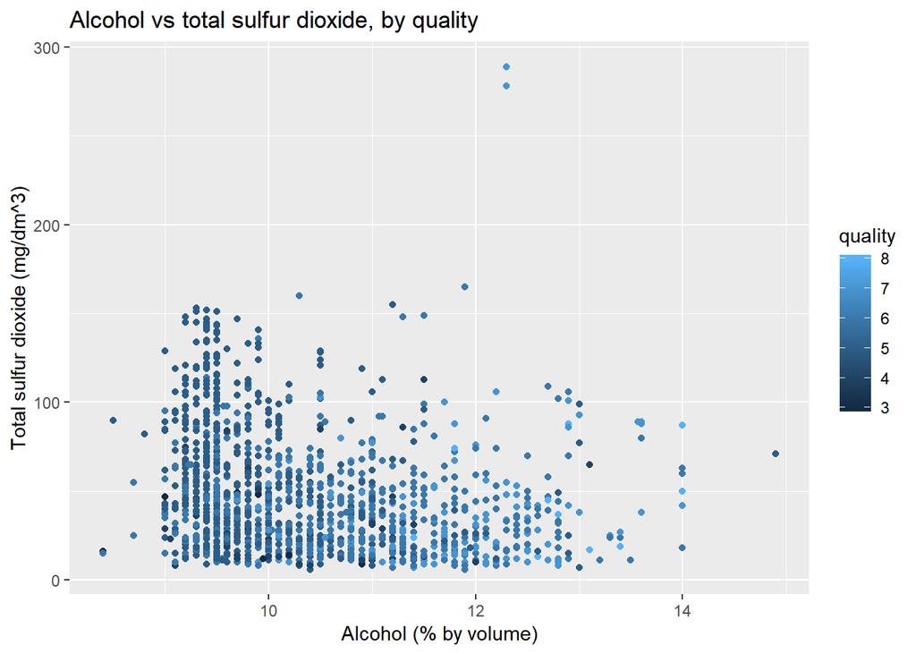

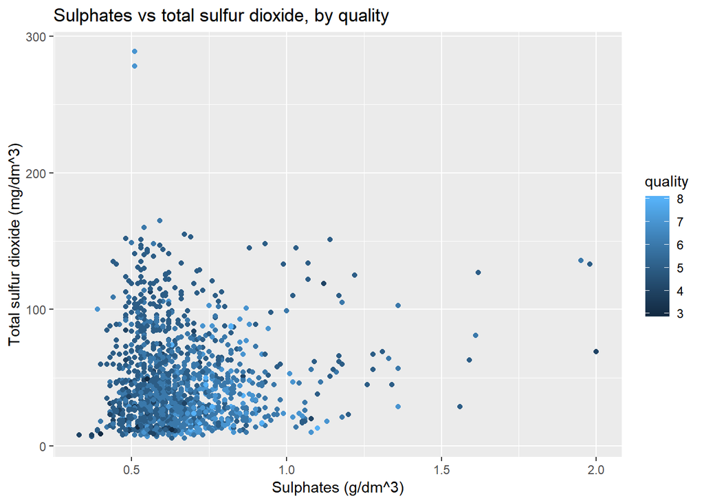

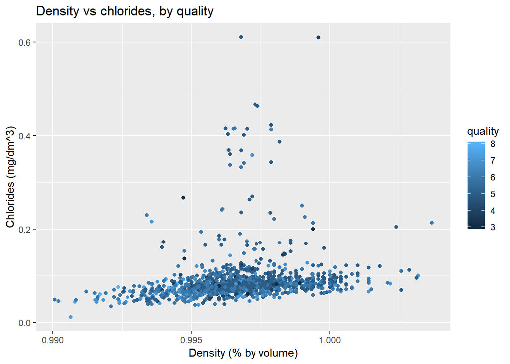

As it can be noticed, it is a little bit difficult to see the different categories of qualities in only one graph, that is why there are some facet grids below, so the different distribution for different qualities are clear.

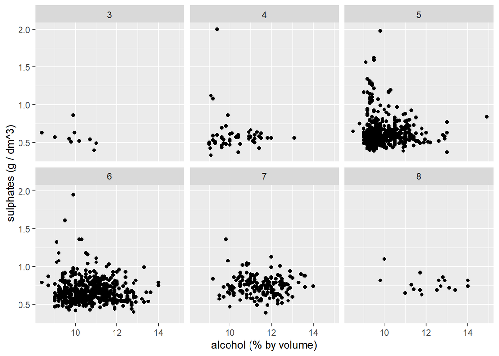

Through the graphs above, it is clear that for medium quality (i.e. for values 5) the distribution is higher on the bottom left of the graph, indicating lower values for sulphates and alcohol. For quality a little higher, 6, the distribution tends to go to the middle of the graph, but still in the bottom, indicating values a little higher for alcohol. The interesting part is for the highest qualities 7 and 8, the distribution tends to get little far from the minium values of sulphates while alcohol levels continues increasing.

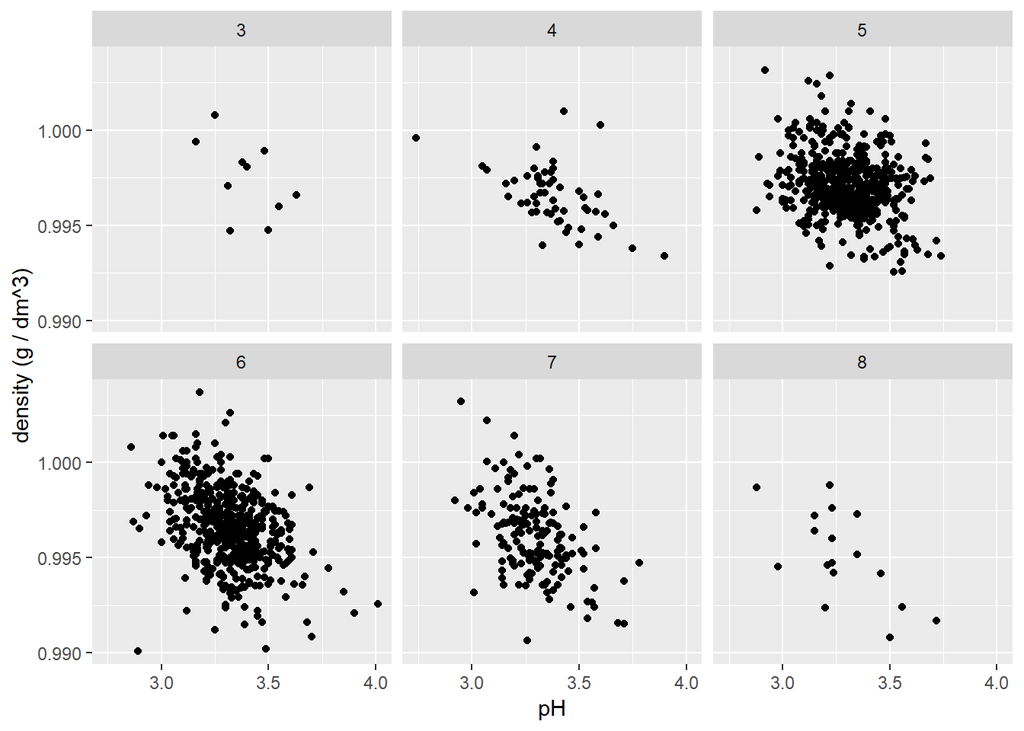

The concentration seems to be always in the center of the graph for all quality levels.

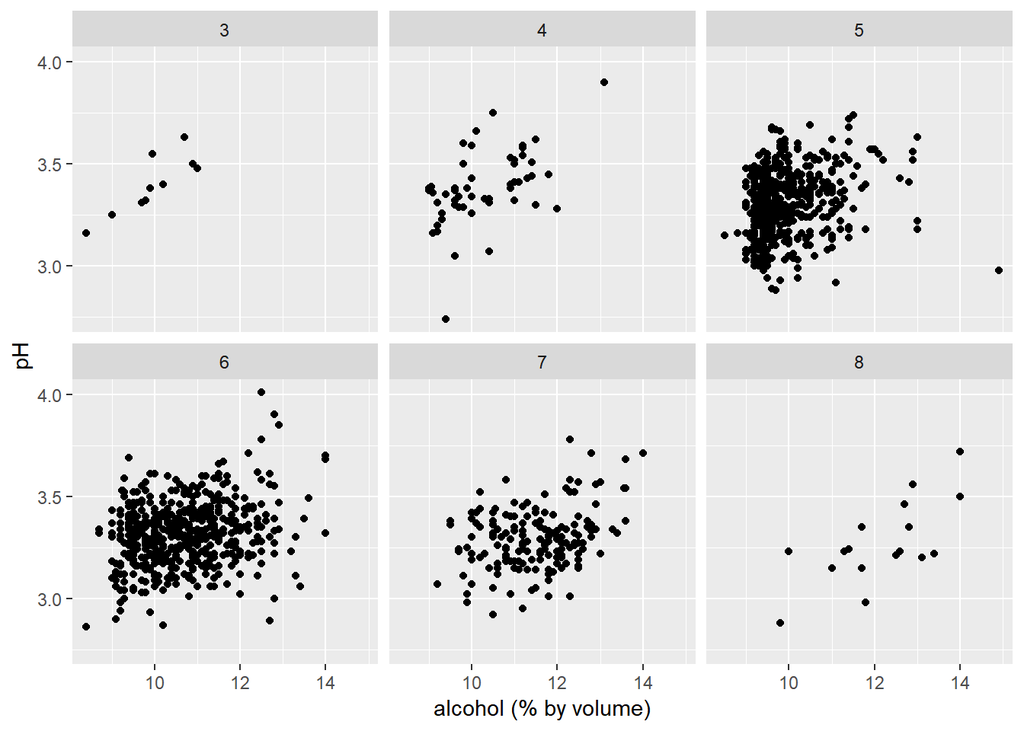

Here we notice a tendency for the points concentrate from the left to the right of the graphs, as the quality grows. The range of values that contains the points in the vertical direction doesn’t seem to change significantly.

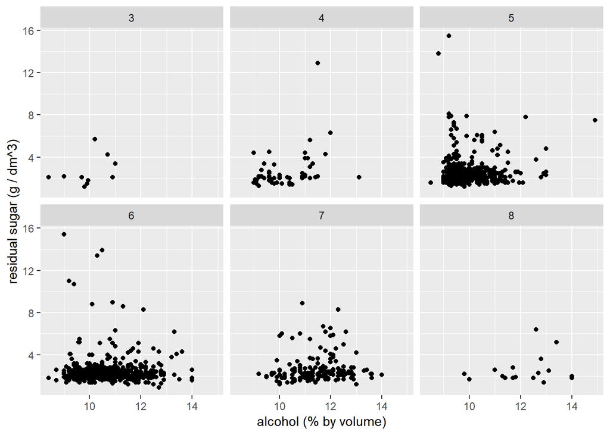

Residual sugar doesn’t seem to be relavant to evaluate quality of wine.

# Multivariate Analysis

### Talk about some of the relationships you observed in this part of the investigation. Were there features that strengthened each other in terms of looking at your feature(s) of interest?

The combination of the 2 characteristics that most seemed to have higher correlation with quality, when combined together, can show some more insights. The 2 features that individually seemed to be the ones who showed more insights about our feature of interest, when combined together, could give us some insights, but not as significant to certificate a good correlation. Other features, even combined, couldn’t give us any good insight, e.g. for pH vs Density facet grid by quality, all points seems to be concentrated on the same area for different facets, leading us to think there is no clear correlation among these features.

### Were there any interesting or surprising interactions between features?

It was surprising to notice that the sulphates and alcohol are the main characteristics that are pleasant for the human taste, since the quality feature values are based on sensory data according to the source’s information.

# Final Plots and Summary

### Plot One

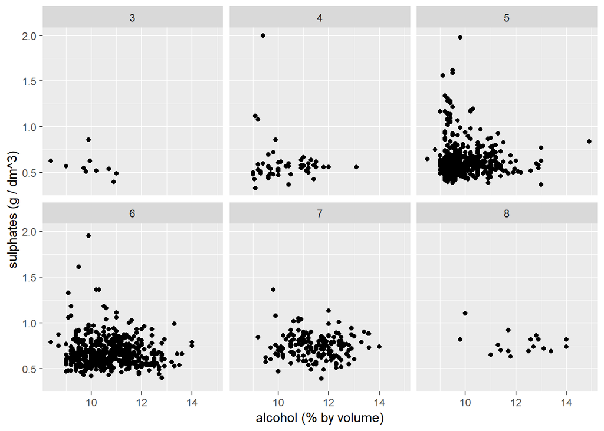

Here is the graph combining the two features that seemed to show more insights about quality of wine than the others presented in the dataset.

### Plot Two

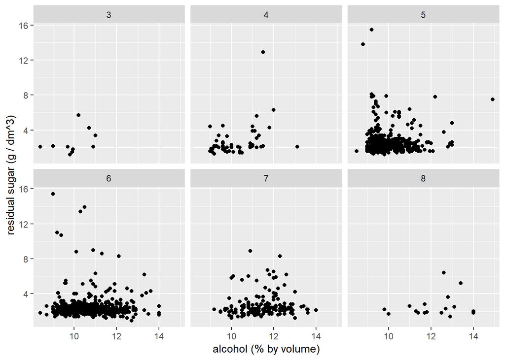

Here is a facet grid graph to enforce that the sweetness of a wine may not be one super relevant feature to be consirdered when evaluating its quality.

### Plot Three

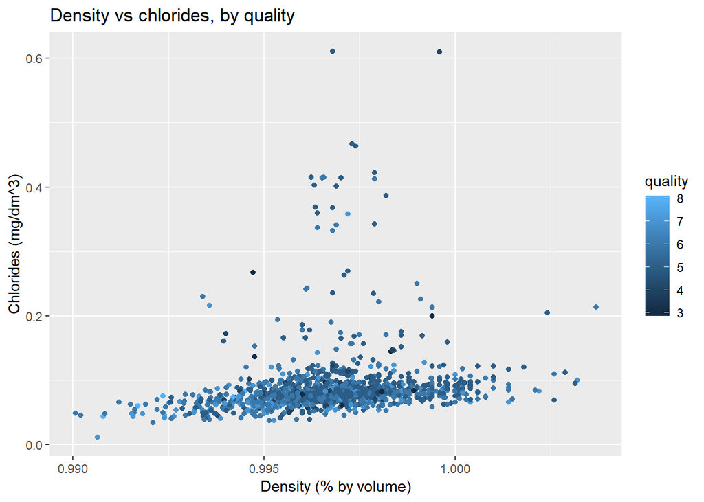

The final plot for the combinantion of density and chlorides, it may not be relevant to determine whether a wine is good or not, but we can learn that there is a linear dependency between its concentration of chlorides and its density.

# Reflection

This exploratory data analysis could bring some points of discussion: Based on the data source information, the quality feature was extracted from sensorial data and all other features were extracted through physicochemical tests. Another point is that some of these physicochemical may be correlated to each other, e.g. the pH level and the presence of acid. So one difficulty found in these analysis was to find which of the features are not related to each other and could bring us insights about the difference between a good and not so tasty wine. It is kind of intuitive to think that a sweeter wine tends to be more pleasant. But does it? The analysis shows that the observations of quality 5, 6, 7 and 8 are all occupying almost the same region of bottom of the graph (on plot 2), i.e., a sweeter wine doesn’t make it better. The surprise here was to check that alcohol influences a lot, the more percentage of alcohol a wine has, the more pleasant it becomes, the reason can be of several ones, but this gets out of the scope of this work. Other surprise is that sulphates also can influence (less than alcohol). According to the data information, sulphates are used as antimicrobial and antioxidant additives and for some reason their concentration tend to grow as quality grows. Some techniques of suppervised learning could be applied here in order to achieve better results and get some better features with feature selection methods.

## Reference

P. Cortez, A. Cerdeira, F. Almeida, T. Matos and J. Reis.  
Modeling wine preferences by data mining from physicochemical properties.  
In Decision Support Systems, Elsevier, 47(4):547-553. ISSN: 0167-9236.